# US Counties Coronavirus Cases and Deaths Trends

CA's [Blueprint for a Safer Economy](https://www.cdph.ca.gov/Programs/CID/DCDC/Pages/COVID-19/COVID19CountyMonitoringOverview.aspx) assigns each county [to a tier](https://www.cdph.ca.gov/Programs/CID/DCDC/Pages/COVID-19/COVID19CountyMonitoringOverview.aspx) based on case rate and test positivity rate. What's opened / closed [under each tier](https://www.cdph.ca.gov/Programs/CID/DCDC/CDPH%20Document%20Library/COVID-19/Dimmer-Framework-September_2020.pdf).

Tiers, from most severe to least severe, categorizes coronavirus spread as **widespread;** **substantial;** **moderate;** **or minimal.**

We apply CA's tier categories to other US counties to help us understand the severity of the spread.

**Related daily reports:**

1. **[CA counties report on cases, deaths, and hospitalizations](https://cityoflosangeles.github.io/covid19-indicators/ca-county-trends.html)**
2. **[Los Angeles County, detailed indicators](https://cityoflosangeles.github.io/covid19-indicators/coronavirus-stats.html)**
3. **[Los Angeles County neighborhoods report on cases and deaths](https://cityoflosangeles.github.io/covid19-indicators/la-neighborhoods-trends.html)**

Code available in GitHub: https://github.com/CityOfLosAngeles/covid19-indicators  
Get informed with [public health research](https://github.com/CityOfLosAngeles/covid19-indicators/blob/master/reopening-sources.md)

Report updated: 5/28/22; data available through 5/27/22

**Cases chart, explained**

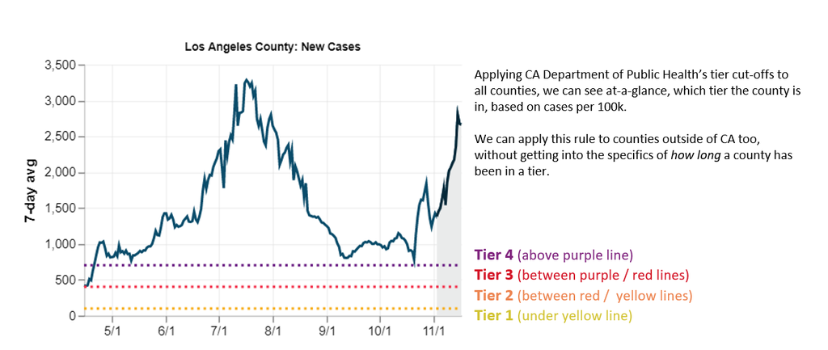

## Select by Major City

**Northeast:** Boston, New York City, Philadelphia, Pittsburgh, Bergen, NJ  
**Mid-Atlantic:** Washington DC, Arlington, Fairfax, Richmond  
**Midwest:** Chicago, Madison, Cincinnati, Lexington, Minneapolis, St Louis  
**Southeast:** Charlotte, Columbia, Memphis, Nashville, Knoxville, Atlanta, Orlando  
**South:** Austin, Dallas, Houston, Oklahoma City, New Orleans  
**West / Northwest:** Portland, Seattle, Phoenix, Las Vegas, Salt Lake City, Denver, Alburquerque  
**California:** [All CA counties](https://cityoflosangeles.github.io/covid19-indicators/ca-county-trends.html)

Note for *small values*: If the 7-day rolling average of new cases or new deaths is under 10, the 7-day rolling average is listed for the past week, rather than a percent change. Given that it is a rolling average, decimals are possible, and are rounded to 1 decimal place.

## Northeast

Boston (Suffolk, MA)

As of 5/27/22, there were **231,650** total cases and **2,016** total deaths.  
In the past week, new cases grew by **-25.6%**; new deaths went from **0.7** to **0.7**.  
New cases are **6.1x** higher than the Tier 4 cut-off. *(1 = Tier 4 widespread cut-off; 2 = new cases are 2x higher than the Tier 4 cut-off)*.  
In the past week, the doubling time went from **293 days** to **399 days** *(longer doubling time is better)*.

[figure not shown]

Return to top

New York City (New York, NY)

As of 5/27/22, there were **458,605** total cases and **5,484** total deaths.  
In the past week, new cases grew by **-16.5%**; new deaths went from **1.6** to **1.4**.  
New cases are **1.5x** higher than the Tier 4 cut-off. *(1 = Tier 4 widespread cut-off; 2 = new cases are 2x higher than the Tier 4 cut-off)*.  
In the past week, the doubling time went from **249 days** to **354 days** *(longer doubling time is better)*.

[figure not shown]

Return to top

Philadelphia (Philadelphia, PA)

As of 5/27/22, there were **323,135** total cases and **5,130** total deaths.  
In the past week, new cases grew by **8.2%**; new deaths went from **0.7** to **2.1**.  
New cases are **3.6x** higher than the Tier 4 cut-off. *(1 = Tier 4 widespread cut-off; 2 = new cases are 2x higher than the Tier 4 cut-off)*.  
In the past week, the doubling time went from **519 days** to **483 days** *(longer doubling time is better)*.

[figure not shown]

Return to top

Pittsburgh (Allegheny, PA)

As of 5/27/22, there were **279,182** total cases and **3,348** total deaths.  
In the past week, new cases grew by **20.2%**; new deaths went from **0.6** to **3.0**.  
New cases are **7.1x** higher than the Tier 4 cut-off. *(1 = Tier 4 widespread cut-off; 2 = new cases are 2x higher than the Tier 4 cut-off)*.  
In the past week, the doubling time went from **323 days** to **272 days** *(longer doubling time is better)*.

[figure not shown]

Return to top

Bergen County (Bergen, NJ)

As of 5/27/22, there were **247,735** total cases and **3,469** total deaths.  
In the past week, new cases grew by **-4.7%**; new deaths went from **1.0** to **0.6**.  
New cases are **9.0x** higher than the Tier 4 cut-off. *(1 = Tier 4 widespread cut-off; 2 = new cases are 2x higher than the Tier 4 cut-off)*.  
In the past week, the doubling time went from **279 days** to **292 days** *(longer doubling time is better)*.

[figure not shown]

Return to top

## Mid-Atlantic

Washington DC (District of Columbia, DC)

As of 5/27/22, there were **149,271** total cases and **1,342** total deaths.  
In the past week, new cases grew by **6.2%**; new deaths went from **0.3** to **0.0**.  
New cases are **6.8x** higher than the Tier 4 cut-off. *(1 = Tier 4 widespread cut-off; 2 = new cases are 2x higher than the Tier 4 cut-off)*.  
In the past week, the doubling time went from **354 days** to **299 days** *(longer doubling time is better)*.

[figure not shown]

Return to top

Arlington (Arlington, VA)

As of 5/27/22, there were **48,890** total cases and **323** total deaths.  
In the past week, new cases grew by **4.7%**; new deaths went from **0.1** to **0.0**.  
New cases are **11.9x** higher than the Tier 4 cut-off. *(1 = Tier 4 widespread cut-off; 2 = new cases are 2x higher than the Tier 4 cut-off)*.  
In the past week, the doubling time went from **148 days** to **146 days** *(longer doubling time is better)*.

[figure not shown]

Return to top

Fairfax (Fairfax, VA)

As of 5/27/22, there were **195,941** total cases and **1,457** total deaths.  
In the past week, new cases grew by **0.2%**; new deaths went from **0.6** to **0.0**.  
New cases are **6.9x** higher than the Tier 4 cut-off. *(1 = Tier 4 widespread cut-off; 2 = new cases are 2x higher than the Tier 4 cut-off)*.  
In the past week, the doubling time went from **203 days** to **207 days** *(longer doubling time is better)*.

[figure not shown]

Return to top

Richmond (Richmond City, VA)

As of 5/27/22, there were **47,423** total cases and **514** total deaths.  
In the past week, new cases grew by **4.9%**; new deaths went from **-0.1** to **0.0**.  
New cases are **5.3x** higher than the Tier 4 cut-off. *(1 = Tier 4 widespread cut-off; 2 = new cases are 2x higher than the Tier 4 cut-off)*.  
In the past week, the doubling time went from **337 days** to **325 days** *(longer doubling time is better)*.

[figure not shown]

Return to top